# Quantitative Methods for Humanities: Election and Conditional Cash Transfer Program in Mexico

Quantitative Methods for Humanities

CUNEF Universidad

# Introduction

Conditional cash transfer (CCT) programs provide regular cash payments to low-income households, conditional on behaviors such as children’s school attendance and preventive health check-ups. They aim to reduce poverty in the short run and improve human capital in the long run.

Mexico’s Progresa program was rolled out experimentally before the 2000 presidential election. Eligible villages received Progresa either **21 months before the election** (early Progresa) or **6 months before the election** (late Progresa). Because this timing was randomly assigned, we can estimate the causal effect of early exposure to Progresa on voter turnout and support for the incumbent party, PRI.

# The Data

The data set (`progresa.csv`) contains 417 precincts. The key variables are:

- `treatment`: 1 if the precinct received early Progresa, 0 if it received late Progresa.
- `t2000`, `pri2000s`: turnout and PRI support in 2000 as shares of the voting-age population.
- `t2000r`, `pri2000v`: official turnout and official PRI vote share in 2000.
- `t1994`, `pri1994s`, `pan1994s`, `prd1994s`: 1994 turnout and party support shares.
- `t1994r`, `pri1994v`, `pan1994v`, `prd1994v`: official 1994 turnout and vote shares.
- `pri1994`, `pan1994`, `prd1994`, `votos1994`: 1994 vote counts.
- `avgpoverty`, `pobtot1994`, `villages`: poverty, population, and precinct characteristics.

```r
progresa <- read.csv("progresa.csv")
progresa$log_pop <- log(progresa$pobtot1994)
```

# Q1. Estimating the Impact of the CCT Program

**Question.** (a) Compare average electoral outcomes between treated and control precincts. (b) Regress `t2000` and `pri2000s` on `treatment`. (c) Interpret and compare the results.

## Q1(a) Average comparison

```r
agg_q1a <- aggregate(cbind(t2000, pri2000s) ~ treatment, data = progresa,
                     FUN = function(x) mean(x, na.rm = TRUE))
agg_q1a$treatment <- ifelse(agg_q1a$treatment == 1, "Early Progresa", "Late Progresa")
print(agg_q1a)
```

```
##        treatment    t2000 pri2000s
## 1  Late Progresa 63.81483 34.48895
## 2 Early Progresa 68.08451 38.11145
```

Early Progresa precincts have higher average turnout and PRI support. The raw differences are 4.27 points for turnout and 3.62 points for PRI support.

## Q1(b) Simple regressions

```r
turnout_model <- lm(t2000 ~ treatment, data = progresa)
pri_model <- lm(pri2000s ~ treatment, data = progresa)

summary(turnout_model)
```

```
##
## Call:
## lm(formula = t2000 ~ treatment, data = progresa)
##
## Residuals:
##     Min      1Q  Median      3Q     Max
## -66.300 -11.700  -1.841   7.778 303.344
##
## Coefficients:
##             Estimate Std. Error t value Pr(>|t|)
## (Intercept)   63.815      2.631  24.255   <2e-16 ***
## treatment      4.270      3.216   1.327    0.185
## ---
## Signif. codes:  0 '***' 0.001 '**' 0.01 '*' 0.05 '.' 0.1 ' ' 1
##
## Residual standard error: 30.91 on 415 degrees of freedom
## Multiple R-squared:  0.004228,   Adjusted R-squared:  0.001829
## F-statistic: 1.762 on 1 and 415 DF,  p-value: 0.1851
```

```r
summary(pri_model)
```

```
##
## Call:
## lm(formula = pri2000s ~ treatment, data = progresa)
##
## Residuals:
##     Min      1Q  Median      3Q     Max
## -37.370 -11.332  -1.673   9.200 104.111
##
## Coefficients:
##             Estimate Std. Error t value Pr(>|t|)
## (Intercept)   34.489      1.554  22.196   <2e-16 ***
## treatment      3.622      1.900   1.907   0.0572 .
## ---
## Signif. codes:  0 '***' 0.001 '**' 0.01 '*' 0.05 '.' 0.1 ' ' 1
##
## Residual standard error: 18.25 on 415 degrees of freedom
## Multiple R-squared:  0.008686,   Adjusted R-squared:  0.006298
## F-statistic: 3.636 on 1 and 415 DF,  p-value: 0.05722
```

# Q2. Adding Pretreatment Covariates

**Question.** (a) Fit a regression for each outcome including `avgpoverty`, `pobtot1994`, `votos1994`, `pri1994`, `pan1994`, and `prd1994`. (b) Compare these estimates with Q1.

```r
turnout_cov <- lm(
  t2000 ~ treatment + avgpoverty + pobtot1994 + votos1994 + pri1994 + pan1994 + prd1994,
  data = progresa
)

pri_cov <- lm(
  pri2000s ~ treatment + avgpoverty + pobtot1994 + votos1994 + pri1994 + pan1994 + prd1994,
  data = progresa
)

summary(turnout_cov)
```

```
##
## Call:
## lm(formula = t2000 ~ treatment + avgpoverty + pobtot1994 + votos1994 +
##     pri1994 + pan1994 + prd1994, data = progresa)
##
## Residuals:
##     Min      1Q  Median      3Q     Max
## -50.173 -11.924  -2.938   6.972 302.183
##
## Coefficients:
##               Estimate Std. Error t value Pr(>|t|)
## (Intercept) 64.0117350 17.3115236   3.698 0.000247 ***
## treatment    4.5494445  3.1346655   1.451 0.147454
## avgpoverty   0.3102553  3.5223779   0.088 0.929855
## pobtot1994  -0.0012128  0.0002316  -5.236 2.63e-07 ***
## votos1994   -0.0261518  0.0354456  -0.738 0.461059
## pri1994      0.0360555  0.0409173   0.881 0.378739
## pan1994      0.0265376  0.0595018   0.446 0.655836
## prd1994      0.0175753  0.0426669   0.412 0.680615
## ---
## Signif. codes:  0 '***' 0.001 '**' 0.01 '*' 0.05 '.' 0.1 ' ' 1
##
## Residual standard error: 29.95 on 409 degrees of freedom
## Multiple R-squared:  0.0785, Adjusted R-squared:  0.06273
## F-statistic: 4.978 on 7 and 409 DF,  p-value: 2.01e-05
```

```r
summary(pri_cov)
```

```
##
## Call:
## lm(formula = pri2000s ~ treatment + avgpoverty + pobtot1994 +
##     votos1994 + pri1994 + pan1994 + prd1994, data = progresa)
##
## Residuals:
##     Min      1Q  Median      3Q     Max
## -32.297  -9.854  -1.322   6.468  94.918
##
## Coefficients:
##               Estimate Std. Error t value Pr(>|t|)
## (Intercept) 37.9500862  9.4239516   4.027 6.73e-05 ***
## treatment    2.9277395  1.7064319   1.716  0.08697 .
## avgpoverty   0.5329801  1.9174926   0.278  0.78119
## pobtot1994  -0.0004996  0.0001261  -3.962 8.77e-05 ***
## votos1994   -0.0417278  0.0192957  -2.163  0.03116 *
## pri1994      0.0624589  0.0222744   2.804  0.00529 **
## pan1994     -0.0487349  0.0323913  -1.505  0.13321
## prd1994     -0.0287363  0.0232268  -1.237  0.21672
## ---
## Signif. codes:  0 '***' 0.001 '**' 0.01 '*' 0.05 '.' 0.1 ' ' 1
##
## Residual standard error: 16.3 on 409 degrees of freedom
## Multiple R-squared:  0.2206, Adjusted R-squared:  0.2073
## F-statistic: 16.54 on 7 and 409 DF,  p-value: < 2.2e-16
```

The adjusted treatment estimates remain positive: 4.55 for turnout and 2.93 for PRI support. They are close to the simple estimates, which is what we would expect under successful random assignment. The substantive conclusion is unchanged: the evidence points in the expected direction, but it is not very precise.

# Q3. Alternative Model Specifications

**Question.** (a) Replace count predictors with share-based equivalents (`t1994`, `pri1994s`, `pan1994s`, `prd1994s`). (b) Log-transform `pobtot1994`. (c) Include `avgpoverty` and compare model fit.

```r
turnout_alt <- lm(
  t2000 ~ treatment + log_pop + avgpoverty + t1994 + pri1994s + pan1994s + prd1994s,
  data = progresa
)

pri_alt <- lm(
  pri2000s ~ treatment + log_pop + avgpoverty + t1994 + pri1994s + pan1994s + prd1994s,
  data = progresa
)

summary(turnout_alt)
```

```
##
## Call:
## lm(formula = t2000 ~ treatment + log_pop + avgpoverty + t1994 +
##     pri1994s + pan1994s + prd1994s, data = progresa)
##
## Residuals:
##      Min       1Q   Median       3Q      Max
## -119.044   -7.248   -1.180    5.579  176.967
##
## Coefficients:
##             Estimate Std. Error t value Pr(>|t|)
## (Intercept)  19.7984    14.4292   1.372  0.17078
## treatment    -0.1530     1.8182  -0.084  0.93299
## log_pop      -3.2471     1.1678  -2.780  0.00568 **
## avgpoverty    2.8621     1.8954   1.510  0.13180
## t1994         0.6605     0.1292   5.112 4.91e-07 ***
## pri1994s      0.1943     0.1371   1.417  0.15720
## pan1994s      0.6374     0.2121   3.005  0.00282 **
## prd1994s      0.3065     0.1471   2.084  0.03780 *
## ---
## Signif. codes:  0 '***' 0.001 '**' 0.01 '*' 0.05 '.' 0.1 ' ' 1
##
## Residual standard error: 17.31 on 409 degrees of freedom
## Multiple R-squared:  0.6921, Adjusted R-squared:  0.6868
## F-statistic: 131.3 on 7 and 409 DF,  p-value: < 2.2e-16
```

```r
summary(pri_alt)
```

```
##
## Call:
## lm(formula = pri2000s ~ treatment + log_pop + avgpoverty + t1994 +
##     pri1994s + pan1994s + prd1994s, data = progresa)
##
## Residuals:
##     Min      1Q  Median      3Q     Max
## -61.330  -7.237  -0.430   6.116  55.869
##
## Coefficients:
##             Estimate Std. Error t value Pr(>|t|)
## (Intercept) 35.85174    9.98288   3.591 0.000369 ***
## treatment    0.23547    1.25790   0.187 0.851602
## log_pop     -4.62934    0.80798  -5.730 1.96e-08 ***
## avgpoverty   2.47163    1.31133   1.885 0.060161 .
## t1994        0.03257    0.08939   0.364 0.715792
## pri1994s     0.51047    0.09488   5.380 1.26e-07 ***
## pan1994s    -0.18384    0.14676  -1.253 0.211052
## prd1994s    -0.05293    0.10175  -0.520 0.603192
## ---
## Signif. codes:  0 '***' 0.001 '**' 0.01 '*' 0.05 '.' 0.1 ' ' 1
##
## Residual standard error: 11.98 on 409 degrees of freedom
## Multiple R-squared:  0.5794, Adjusted R-squared:  0.5722
## F-statistic: 80.48 on 7 and 409 DF,  p-value: < 2.2e-16
```

```r
fit_comparison <- data.frame(
  outcome = c("Turnout", "Turnout", "PRI support", "PRI support"),
  model = c("Q2 count covariates", "Q3 share/log covariates",
            "Q2 count covariates", "Q3 share/log covariates"),
  adjusted_R2 = c(adjr2(turnout_cov), adjr2(turnout_alt), adjr2(pri_cov), adjr2(pri_alt))
)
print(fit_comparison)
```

```
##       outcome                   model adjusted_R2
## 1     Turnout     Q2 count covariates  0.06273301
## 2     Turnout Q3 share/log covariates  0.68683309
## 3 PRI support     Q2 count covariates  0.20725162
## 4 PRI support Q3 share/log covariates  0.57216205
```

# Q4. Examining Balance of Pretreatment Variables

**Question.** (a) Use box plots to compare treatment and control groups for `pobtot1994`, `avgpoverty`, `t1994`, and `pri1994s`. (b) Comment on the patterns.

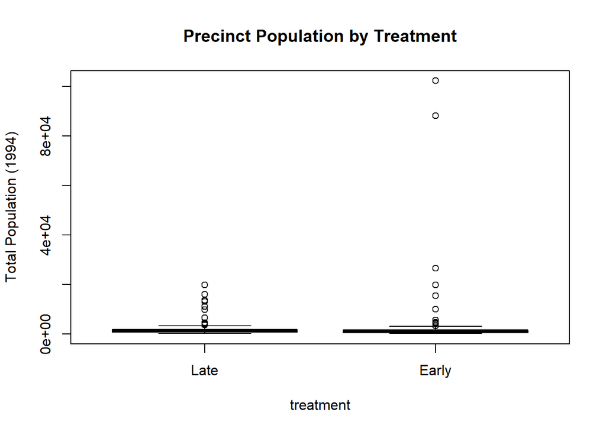

```r
boxplot(pobtot1994 ~ treatment, data = progresa,
        names = c("Late", "Early"),
        ylab = "Total Population (1994)",
        main = "Precinct Population by Treatment")
```

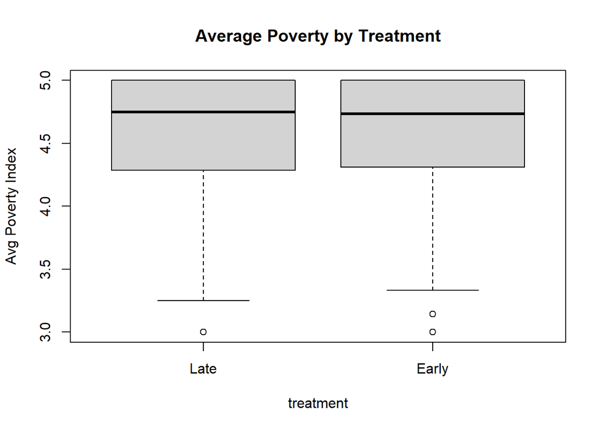

```r
boxplot(avgpoverty ~ treatment, data = progresa,
        names = c("Late", "Early"),
        ylab = "Avg Poverty Index",
        main = "Average Poverty by Treatment")
```

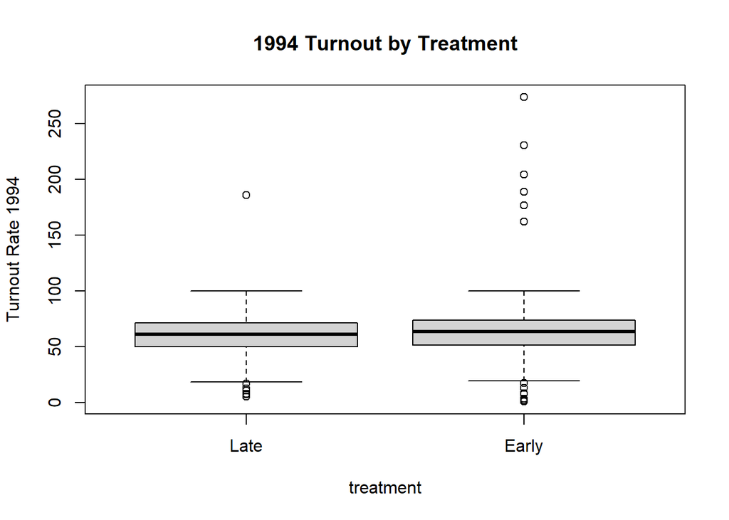

```r
boxplot(t1994 ~ treatment, data = progresa,
        names = c("Late", "Early"),
        ylab = "Turnout Rate 1994",
        main = "1994 Turnout by Treatment")
```

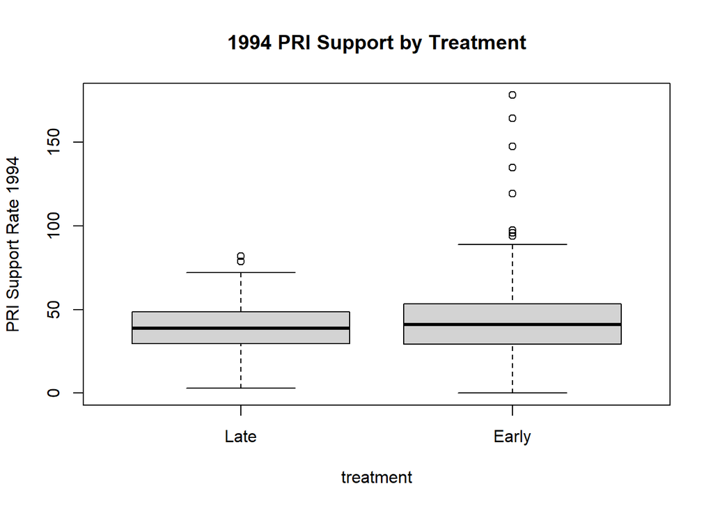

```r
boxplot(pri1994s ~ treatment, data = progresa,
        names = c("Late", "Early"),
        ylab = "PRI Support Rate 1994",
        main = "1994 PRI Support by Treatment")
```

The central parts of the distributions look broadly similar across treatment groups, especially for poverty and prior electoral behavior. There are some large outliers, particularly in population and previous turnout/PRI support, but the box plots do not show a clear systematic imbalance in the typical treated and control precinct.

# Q5. Using Official Turnout and Vote Shares

**Question.** (a) Use official turnout (`t2000r`) and official PRI vote share (`pri2000v`). (b) Estimate the treatment effect with `avgpoverty`, log population, and previous official election variables. (c) Interpret the results.

```r
off_turnout <- lm(
  t2000r ~ treatment + avgpoverty + log_pop + t1994r + pri1994v + pan1994v + prd1994v,
  data = progresa
)

off_pri <- lm(
  pri2000v ~ treatment + avgpoverty + log_pop + t1994r + pri1994v + pan1994v + prd1994v,
  data = progresa
)

summary(off_turnout)
```

```
##
## Call:
## lm(formula = t2000r ~ treatment + avgpoverty + log_pop + t1994r +
##     pri1994v + pan1994v + prd1994v, data = progresa)
##
## Residuals:
##     Min      1Q  Median      3Q     Max
## -38.041  -4.555   0.029   5.010  29.069
##
## Coefficients:
##             Estimate Std. Error t value Pr(>|t|)
## (Intercept) 33.47237    8.85553   3.780 0.000180 ***
## treatment   -1.08094    0.81683  -1.323 0.186465
## avgpoverty  -0.27734    0.88768  -0.312 0.754874
## log_pop     -0.27878    0.47487  -0.587 0.557487
## t1994r       0.22238    0.03102   7.168 3.59e-12 ***
## pri1994v     0.12473    0.05489   2.272 0.023586 *
## pan1994v     0.27356    0.07257   3.770 0.000188 ***
## prd1994v     0.11323    0.05790   1.955 0.051209 .
## ---
## Signif. codes:  0 '***' 0.001 '**' 0.01 '*' 0.05 '.' 0.1 ' ' 1
##
## Residual standard error: 7.795 on 408 degrees of freedom
##   (1 observation deleted due to missingness)
## Multiple R-squared:  0.1809, Adjusted R-squared:  0.1669
## F-statistic: 12.87 on 7 and 408 DF,  p-value: 5.603e-15
```

```r
summary(off_pri)
```

```
##
## Call:
## lm(formula = pri2000v ~ treatment + avgpoverty + log_pop + t1994r +
##     pri1994v + pan1994v + prd1994v, data = progresa)
##
## Residuals:
##     Min      1Q  Median      3Q     Max
## -37.876  -7.686   1.072   7.461  34.758
##
## Coefficients:
##             Estimate Std. Error t value Pr(>|t|)
## (Intercept) 50.22721   14.43904   3.479 0.000558 ***
## treatment    0.80172    1.33185   0.602 0.547536
## avgpoverty   3.19082    1.44737   2.205 0.028042 *
## log_pop     -2.59489    0.77428  -3.351 0.000879 ***
## t1994r      -0.08612    0.05058  -1.703 0.089421 .
## pri1994v     0.35738    0.08950   3.993 7.73e-05 ***
## pan1994v    -0.48863    0.11832  -4.130 4.41e-05 ***
## prd1994v    -0.24158    0.09441  -2.559 0.010862 *
## ---
## Signif. codes:  0 '***' 0.001 '**' 0.01 '*' 0.05 '.' 0.1 ' ' 1
##
## Residual standard error: 12.71 on 408 degrees of freedom
##   (1 observation deleted due to missingness)
## Multiple R-squared:  0.4836, Adjusted R-squared:  0.4747
## F-statistic: 54.58 on 7 and 408 DF,  p-value: < 2.2e-16
```

# Q6. Exploring Heterogeneous Treatment Effects

**Question.** (a) Fit a model with `treatment`, log population, `avgpoverty`, `avgpoverty^2`, and interactions between treatment and the poverty terms. (b) Estimate treatment effects at different poverty levels. (c) Plot and comment on the trend.

```r
het_mod <- lm(
  t2000 ~ treatment * avgpoverty + treatment * I(avgpoverty^2) + log_pop,
  data = progresa
)
summary(het_mod)
```

```
##
## Call:
## lm(formula = t2000 ~ treatment * avgpoverty + treatment * I(avgpoverty^2) +
##     log_pop, data = progresa)
##
## Residuals:
##     Min      1Q  Median      3Q     Max
## -41.389 -13.710  -2.435   7.475 280.248
##
## Coefficients:
##                           Estimate Std. Error t value Pr(>|t|)
## (Intercept)                125.832    186.017   0.676    0.499
## treatment                   34.809    211.509   0.165    0.869
## avgpoverty                  29.018     85.369   0.340    0.734
## I(avgpoverty^2)             -3.794      9.790  -0.388    0.699
## log_pop                    -16.114      1.662  -9.693   <2e-16 ***
## treatment:avgpoverty       -18.037     98.477  -0.183    0.855
## treatment:I(avgpoverty^2)    2.321     11.342   0.205    0.838
## ---
## Signif. codes:  0 '***' 0.001 '**' 0.01 '*' 0.05 '.' 0.1 ' ' 1
##
## Residual standard error: 27.78 on 410 degrees of freedom
## Multiple R-squared:  0.2051, Adjusted R-squared:  0.1935
## F-statistic: 17.63 on 6 and 410 DF,  p-value: < 2.2e-16
```

```r
poverty_levels <- quantile(progresa$avgpoverty, probs = c(.25, .50, .75), na.rm = TRUE)

effect_table <- data.frame(avgpoverty = as.numeric(poverty_levels))
effect_table$effect <- coef(het_mod)["treatment"] +
  coef(het_mod)["treatment:avgpoverty"] * effect_table$avgpoverty +
  coef(het_mod)["treatment:I(avgpoverty^2)"] * effect_table$avgpoverty^2
print(effect_table)
```

```
##   avgpoverty    effect
## 1   4.285714 0.1420235
## 2   4.750000 1.5053299
## 3   5.000000 2.6539045
```

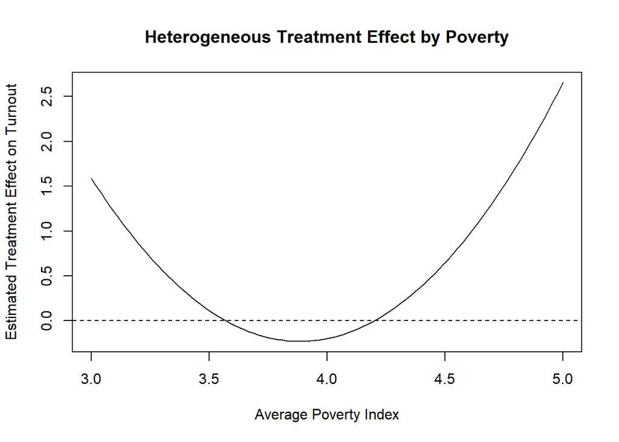

```r
grid <- seq(min(progresa$avgpoverty, na.rm = TRUE),
            max(progresa$avgpoverty, na.rm = TRUE),
            length.out = 100)

pred0 <- data.frame(treatment = 0,
                    avgpoverty = grid,
                    log_pop = mean(progresa$log_pop, na.rm = TRUE))
pred1 <- pred0
pred1$treatment <- 1

effect <- predict(het_mod, newdata = pred1) - predict(het_mod, newdata = pred0)

plot(grid, effect, type = "l",
     xlab = "Average Poverty Index",
     ylab = "Estimated Treatment Effect on Turnout",
     main = "Heterogeneous Treatment Effect by Poverty")
abline(h = 0, lty = 2)
```

The estimated effect varies nonlinearly with poverty. In the current fit, the curve is roughly U-shaped: the effect is more positive at low and high poverty levels and closer to zero, or slightly negative, around the middle. However, the interaction terms are not statistically significant, so this should be read as exploratory rather than strong evidence of heterogeneous effects.